# final project

Author

Jill Tyrrell

## Introduction

The data set I chose includes popular fast food chains, items on their menu, and the nutritional facts of their items. The nutritional facts include calories, fat, carbohydrates, sugar, etc. I will be looking into the healthiest fast food item and healthiest fast food chain according to this data set.

## Main Question: what is the healiest fast food meal?

```r
library(tidyverse)
library(here)
fastfood <- read_csv(here("data/fastfood_calories.csv"))
```

```
──────────────────────────────────────────────────────── Delimiter: "," chr
(3): restaurant, item, salad dbl (15): ...1, calories, cal_fat, total_fat,
sat_fat, trans_fat, cholestero...
```

## ggplot2 and stringr, fct_reorder

## Comparing Similar Items/Ingredients

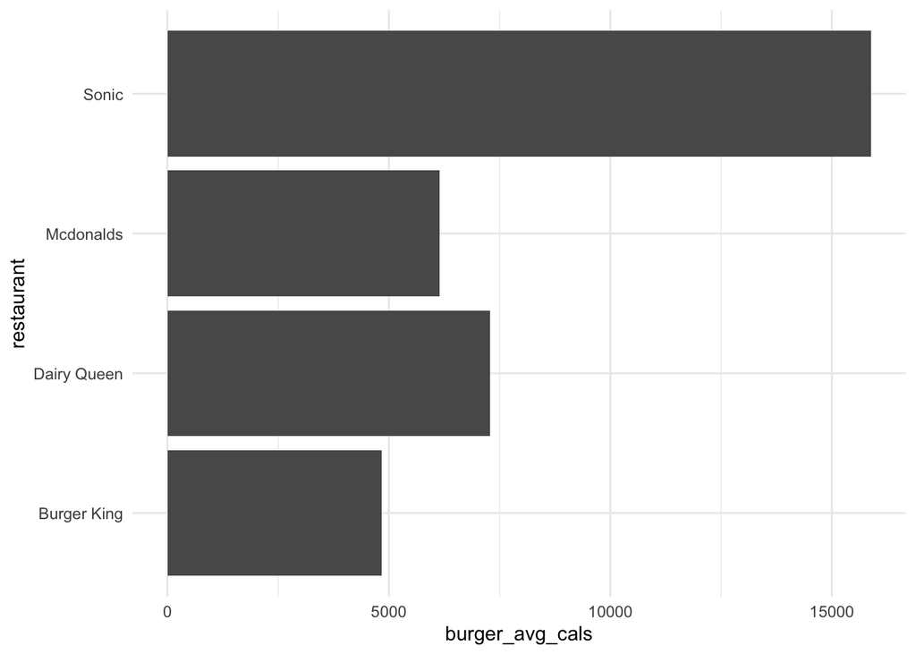

```r
library(ggplot2)
fastfood <- fastfood |> mutate(item = str_to_lower(item))

burgers <- fastfood |> filter(str_detect(item, pattern = "burger" ) == TRUE) |>
  group_by(restaurant) |>
  mutate(burger_avg_cals = mean(calories))

## average calories in burger items per restaurant
ggplot(data = burgers, aes(x = restaurant, y = burger_avg_cals)) +
  geom_col() +
  coord_flip() +
  theme_minimal()
```

## finding the highest and lowest calorie food on each menu

```r
highest_cal_items <- fastfood |>
  group_by(restaurant) |>
  filter(calories == max(calories)) |>
  select(calories, restaurant, item)


lowest_cal_items <- fastfood |>
  group_by(restaurant) |>
  filter(calories == min(calories)) |>
  select(calories, restaurant, item)
```

## finding the average nutrional values for each restaurant

```r
nutritional_values <- fastfood |>
  group_by(restaurant) |>
  summarise(avg_cals = mean(calories),
            avg_totalfat = mean(total_fat),
            avg_cholesterol = mean(cholesterol),
            avg_sodium = mean(sodium),
            avg_carbs = mean(total_carb),
            avg_sugar = mean(sugar),
            avg_protein = mean(protein),
            avg_calcium = mean(calcium))
```

## case_when and factors with forcats

## labeling calories to high, medium, and low

```r
library(forcats)
fastfood1 <- fastfood |>
  arrange(desc(calories)) |>
   mutate(cal_rank =
                          case_when(calories >= 800 ~ "high",
                                    calories < 800 & calories >= 300  ~ "medium",
                                    calories > 300 & calories >= 0 ~ "low"))
```

## comparing calories and transfat

```r
cals_v_transfat <- fastfood |>
  select(calories, trans_fat, restaurant)
cals_v_transfat
```

```
# A tibble: 515 × 3
   calories trans_fat restaurant
      <dbl>     <dbl> <chr>
 1      380       0   Mcdonalds
 2      840       1.5 Mcdonalds
 3     1130       3   Mcdonalds
 4      750       0.5 Mcdonalds
 5      920       0.5 Mcdonalds
 6      540       1   Mcdonalds
 7      300       0.5 Mcdonalds
 8      510       0   Mcdonalds
 9      430       1   Mcdonalds
10      770       2.5 Mcdonalds
# … with 505 more rows
```

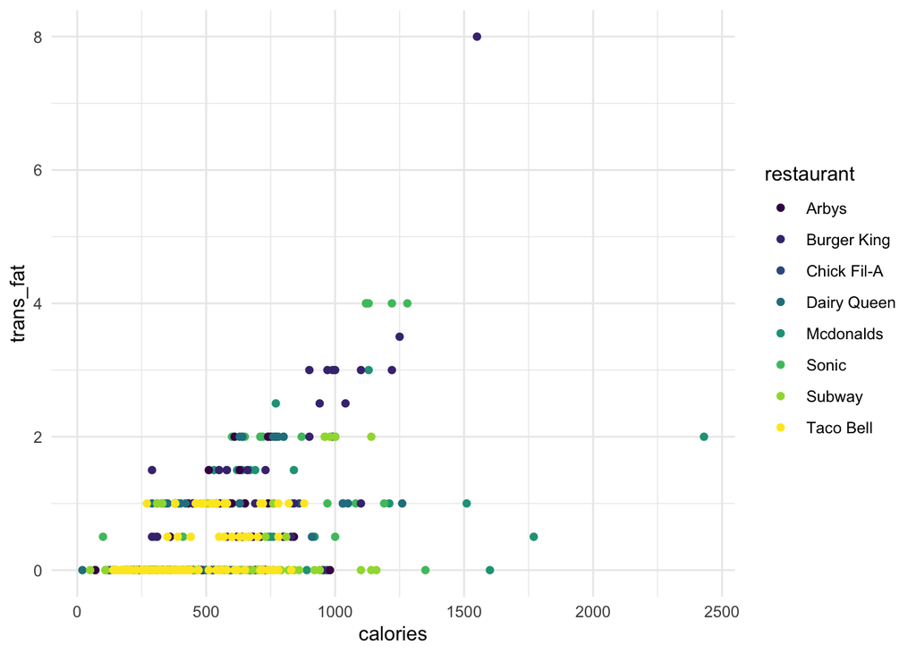

```r
ggplot(data = cals_v_transfat, aes(x = calories, y = trans_fat)) +
  geom_point(aes(color = restaurant)) +
  scale_color_viridis_d() +
  theme_minimal()
```

```r
lowest_transfat_item <- fastfood |>
  group_by(restaurant) |>
  filter(trans_fat == min(trans_fat, na.rm = TRUE)) |>
  select(trans_fat, restaurant, item, sodium)
```

## calories and sodium

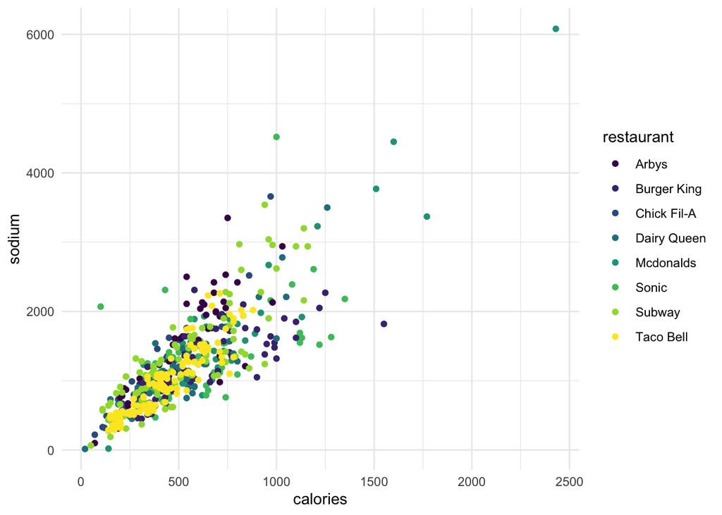

```r
cals_v_sodium <- fastfood |>
  select(calories, sodium, restaurant)

ggplot(data = cals_v_sodium, aes(x = calories, y = sodium)) +
  geom_point(aes(color = restaurant)) +
  scale_color_viridis_d() +
  theme_minimal()
```

## sodium and trans_fat

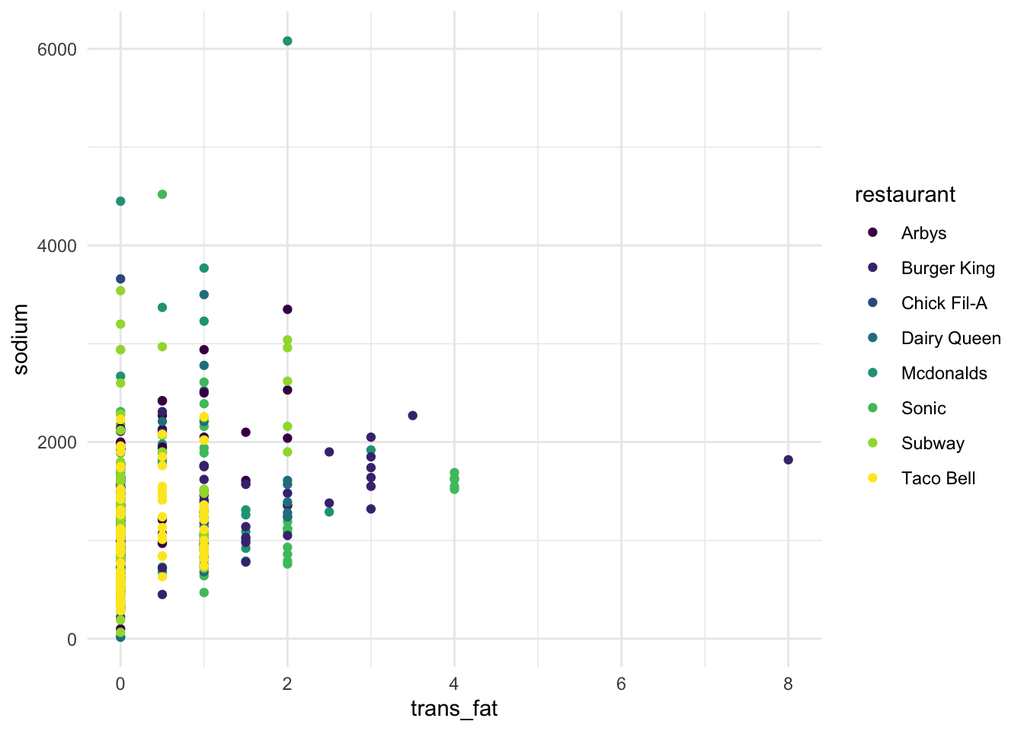

```r
low_transfat_sodium <- lowest_transfat_item |>
  filter(sodium == min(sodium, na.rm = TRUE))

ggplot(data = fastfood, aes(x = trans_fat, y = sodium)) +
  geom_point(aes(color = restaurant)) +
  scale_color_viridis_d() +
  theme_minimal()
```

```r
health <- fastfood |>
  mutate(health = calories + sat_fat + trans_fat + cholesterol + sodium + sugar)
healthiest_item <- health |>
  filter(health == min(health)) |>
  select(restaurant, item, health)
```

## healthiest restaurant

```r
healthiest_restaurant <- fastfood |>
  mutate(health = calories + sat_fat + trans_fat + cholesterol + sodium + sugar) |>
  group_by(restaurant) |>
  mutate(avg_health = mean(health)) |>
  select(restaurant, avg_health, health) |>
  filter(avg_health == min(avg_health)) |>
  arrange(avg_health)
```

## Reflection

I created graphs to help visualize the data that I wanted to look at. This made it easier for me to see overall trends and form more broad conclusions about the data. Throughout this project, I looked at ggplot and dpylr notes the most. This helped refreshed my memory on how to wrangle the data in order to graph the specific data I wanted to look at. The main finding I would want someone reading my project to come away with is how the different nutrition measurements influence the overall health of items on fast food meals. It is also important for people to see which restaurants are considered to be on the “healthier” side compares to other restaurants. Working with this data, I strengthened my overall understanding of the R studio language. In addition, I was able to learn more about the calories, fats, sugars, and carbohydrates that play a role in the overall health of items on these fast food menus.